# Grandma’s Glop Recipe

# Prelude

Many thanks to my r-mentor [Eric Anderson](https://swfsc.noaa.gov/staff.aspx?id=740) for sharing this lesson.

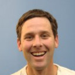

Eric Anderson

We are going to go through using many of the features of R Markdown whilst writing up a recipe that can calculate appropriate quantities if you want to increase the recipe by any factor.

First, we are going to make a subsection dedicated to grandma from whom this recipe came.

## Dedication to grandma

This recipe came from my grandmother whom I always remember used to say:

> You only get to be young once,  
> But you can stay immature forever  
> –grandma

Notice in the above that we used `>` to make a block quote and we *also* used two spaces (which, of course, you cannot see!) at the end of each line to force a line break.

I leave this dedication with a picture of grandma:

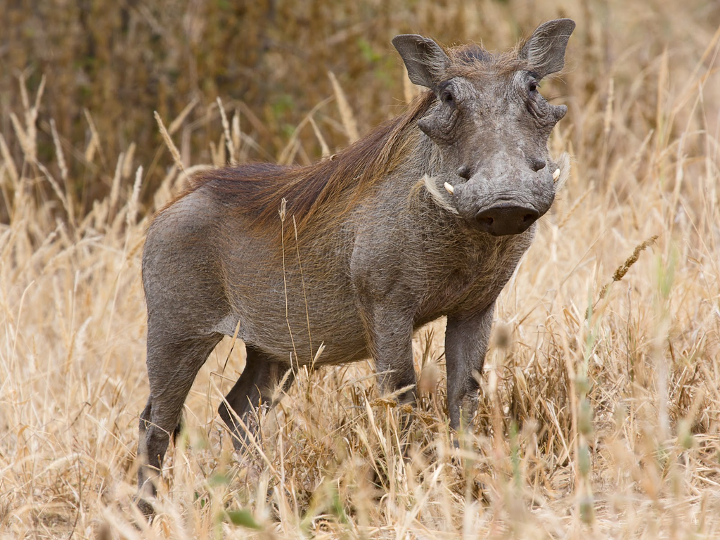

A pic of grandma

We might come back to this Dedication at some point, so we have linked it to a tag. Note that it does not seem you can link to arbitrary text, but you can to section headers.

# The Recipe

## The Ingredients (Static Version)

Let’s list those ingredients for a single recipe’s worth of Grandma’s Glop. We call it “static” because it applies to just a single recipe. We will look at “automagically” doubling, or tripling, or “pi”-ing the recipe in a later section.

### Static List version

You may want to notice what happens if you don’t have two “returns” (line endings), which give you at least one empty line, above the “##”’s used to make the section header—It doesn’t recognize it as a header.

Let’s see, we have already seen how to make text *italic* and **bold**. Did you notice how Rstudio highlights those bits in the text editor window? That is called “Syntax Highlighting” and it is super helpful.

Let’s write our recipe in a list. Be wary! There has to be an empty line above the list *and* the space after the asterisk or number is important (i.e. mandatory)!

- 2 cups flour
- 4 eggs
- 1 Pound of Grandma Gorp:
  - 0.5 pounds raisins
  - 0.5 pounds cashews

  ```r
  # you can indent R code blocks if you want them
  # indented to pertain to list items.
  ```

Notice, the indent level is 4 spaces. You can use a `-` or a `*` or a `+` to start those list items. In fact, you can mix and match them too, as I did, but it is probably better to be consistent. (Use the same symbol within a nested level and different ones between). Hey! did you notice the backticks (upper left of your keyboard— same key as the tilde) around things. Those include inline code-fragments—basically they get printed out in monospaced type (any maybe in a different color). Super useful for variable names like `x_data` or `y_data`.

While we are at it, let’s look at what I have done with the text in the .Rmd file (the text file). Note that I have put plenty of line endings in so that there are not big long lines. This is a good habit to get into because git likes to look at differences between files on a line by line basis. If the lines are long, then it is harder for git to reasonably merge changes. Rstudio’s editor will soft-wrap the lines so that it looks like there are line breaks but there really aren’t. Like this ridiculously long line.

And do keep in mind that a blank line equates to a paragraph break.

### Static table version

We could also have written that stuff out in a table. There are actually lots of ways to write tables. See [this link](http://rmarkdown.rstudio.com/authoring_pandoc_markdown.html#tables).

*Whoa! that is neat, but kind of a lot of work to input. I sure wouldn’t want to do that for a big table! We will investigate ways to automate that. Note that the colons dictate the alignment.*

| What | How Much | Units |
| --- | --- | --- |
| Flour | 2 | cups |
| Eggs | 4 | eggs! |
| Raisins | 1/2 | lbs |
| Cashews | 1/2 | lbs |

## How to make it

Once you have the ingredients, you have to prepare the meal. This is a great task for an ordered list:

1. Break the eggs and scramble them
2. Grind the cashews in a food mill
3. Eat the raisins to keep your energy up because you are going to have a lot of stirring to do. Notice that you can break lines in the text within an item, so long as you don’t leave a blank line. The indenting makes the text source more readable but is not necessary.
4. Add cashews to eggs, stir in flour
5. Mix for 30 minutes.

Note that you can put whatever number you want in the front and the markdown interpreter will figure out which numbers they should be. The numbers must be followed by a period!

## Cooking time: It’s complicated

Now, the big trick to getting grandma’s glop just right is cooking it for the proper length of time. Describing this is going to require that we cite some literature and also that we write down some equations…What fun! Let’s see how we do that with R Markdown. Cooking time $M$ (for minutes) decreases as the square root of the cooking temperature $T$, but increases as the $\frac{3}{2}$-power of the elevation $a$ (for altitude), in feet. For $300^\circ \leq T \leq 500^\circ$ and $0\leq a \leq 5000$, cooking time is
$$M = (20 - \sqrt{T/4}) \times \biggl(\frac{a+5000}{2500}\biggr)^\frac{3}{2}$$
Anyone that is really interested in writing technical mathematical documents should learn to use LaTeX directly. Thankfully, you can imbed R code within LaTeX much as can be done with R Markdown.

We should perhaps qualify this model with a few statements. This model was not empirically derived by rigorous tests, rather we guessed at it given similar work done on cooking times of Chinook salmon at altitude (Satterthwaite *et al.* 2014) and for steelhead at different temperatures (Abadia-Cardoso *et al.* 2013). But please bear in mind that we did not account for the issues noted by Crandall *et al.* (2016) which arise while using next generation oven technology. You can easily add citations by clicking “Addins” and “Insert Citations”

Clearly, it would be nice to have a table of cooking times, $M$, for a few values of $T$ and $a$. Let’s take $T\in\{300, 350, 400, 450, 500\}$ and $a\in\{0, 1250, 2500, 3750, 5000\}$. Holy smokes! There will be 25 rows in that table! I don’t want to write that by hand!

Thankfully, we can use R to do it for us. We make a a data frame of values, then use a nifty function `kable` from the `knitr` package to make the table. Get ready, we are going to use some R:

```r
# first make the data frame
temps <- rep(seq(300,500,50), 5)
alts <- rep(seq(0, 5000, 1250), each=5)
tab <- data.frame(T = temps, a = alts, M = (20-sqrt(temps/4)) * ((alts+5000)/2500) ^ (3/2))
```

And then we print it and it looks like this

Cooking times, $M$, at various temperatures, $T$, and elevations, $a$.

| T | a | M |
| --- | --- | --- |
| 300 | 0 | 32.07365 |
| 350 | 0 | 30.11103 |
| 400 | 0 | 28.28427 |
| 450 | 0 | 26.56854 |
| 500 | 0 | 24.94577 |
| 300 | 1250 | 44.82428 |
| 350 | 1250 | 42.08144 |
| 400 | 1250 | 39.52847 |
| 450 | 1250 | 37.13067 |
| 500 | 1250 | 34.86277 |
| 300 | 2500 | 58.92305 |
| 350 | 2500 | 55.31749 |
| 400 | 2500 | 51.96152 |
| 450 | 2500 | 48.80953 |
| 500 | 2500 | 45.82830 |
| 300 | 3750 | 74.25153 |
| 350 | 3750 | 69.70801 |
| 400 | 3750 | 65.47900 |
| 450 | 3750 | 61.50704 |
| 500 | 3750 | 57.75026 |
| 300 | 5000 | 90.71797 |
| 350 | 5000 | 85.16685 |
| 400 | 5000 | 80.00000 |
| 450 | 5000 | 75.14719 |
| 500 | 5000 | 70.55728 |

## Calculating Recipe Quantities

This could be done several ways, but let us simply look at how we would list the ingredients.

First, make an R code block where we declare the quantities:

```r
amts <- c(Flour = 2, Eggs = 4, Raisins = 0.5, Cashews = 0.5)
mult <- 40 # make a mult-fold version of the recipe
aa <- amts * mult
```

Then access those variables inline in the list. For example: In order to make 40 times the standard recipe, you will need

- 80 cups flour
- 160 eggs
- 40 lbs of Grandma Gorp:
  - 20 lbs raisins
  - 20 lbs cashews

And, if you want to make $\pi$ times the standard recipe you need:

- 6.2831853 cups flour
- 12.5663706 eggs
- 3.1415927 lbs of Grandma Gorp:
  - 1.5707963 lbs raisins
  - 1.5707963 lbs cashews

Of course, had we wanted to, we could have stuck that in a `kable` table, too.

# More notes about markdown

## A note about citations and references

You can define different styles in a “CSL” file which you can put where Rstudio can find it (in your project) and then call it out in the YAML header. You apparently can store your citation database in many different ways. I chose BibTeX because that is what I am used to. The citation data base for this document is `blop.bib` which looks like this:

```
@article{will2014,
  title={A comparison of cooking times for {C}hinook salmon in the {C}alifornia {C}urrent and at higher elevations},
  author={Satterthwaite, William H and Mohr, Michael S and O’Farrell, Michael R and Anderson, Eric C and Banks, Michael A and Bates, Sarah J and Bellinger, M Renee and Borgerson, Lisa A and Crandall, Eric D and Garza, John Carlos and others},
  journal={Transactions of the American Fisheries Society},
  volume={143},
  number={1},
  year={2014},
  publisher={Taylor \& Francis}
}


@article{crandall2016,
  title={Next-generation oven technology and its impact on cooking times for {G}reen {S}turgeon},
  author={Crandall, Eric D and Skaug, Hans J and Barshis, Daniel J},
  journal={Molecular Ecology},
  volume={23},
  number={3},
  pages={502--512},
  year={2016},
  publisher={Wiley Online Library}
}


@article{abadia2013,
  title={Large-scale parentage analysis reveals reproductive patterns and variation in cooking times for steelhead ({\em Oncorhynchus mykiss})},
  author={Abadia-Cardoso, Alicia and Anderson, Eric C and Pearse, Devon E and Carlos Garza, John},
  journal={Molecular Ecology},
  volume={22},
  number={18},
  pages={4733--4746},
  year={2013},
  publisher={Wiley Online Library}
}

@article{boughton2009spatial,
  title={Spatial patterning of habitat for Oncorhynchus mykiss in a system of intermittent and perennial streams},
  author={Boughton, DA and Fish, H and Pope, J and Holt, G},
  journal={Ecology of Freshwater Fish},
  volume={18},
  number={1},
  pages={92--105},
  year={2009},
  publisher={Wiley Online Library}
}
```

Note that by default only the citations in your data base that actually got cited will be included in the References.

It should be pointed out that you can easily grab BibTex-formatted citations from [Google Scholar](http://scholar.google.com).

If you want to use a different bibliography style, browse the styles available at [Zotero Style Repository](https://zotero.org/styles). You can just download them and put them in your project. If we have time, we can try using the *Science* citation style.

Much more about citations with R markdown can be found [here](http://rmarkdown.rstudio.com/authoring_bibliographies_and_citations.html) and you can find plenty of other good links at the bottom of this [page](http://rmarkdown.rstudio.com/).

## Making PDF and Word documents

To make a PDF document you need the TeX typesetting engine. It is free, but many of you probably don’t have it yet.

To make a Word doc, click the down triangle to the right of “Knit HTML” and choose “Knit Word”. Can you figure out what changes in the document? (Again, it is textual and transparent!) Contrast that to the Word document itself—do this at your Unix command prompt (in the right directory of course):

```
cat auto-recipe.docx
```

### Changing styles and templates

Wanna have a different look? Try the “Gear” link to the right of the “Knit HTML” button. Notice how changes there change things in the YAML header.

You can also check out [different YAML themes](https://www.datadreaming.org/post/r-markdown-theme-gallery/)

And let us thank fish (Boughton *et al.* 2009)

## References

Abadia-Cardoso A, Anderson EC, Pearse DE, Carlos Garza J (2013) Large-scale parentage analysis reveals reproductive patterns and variation in cooking times for steelhead (*Oncorhynchus mykiss*). *Molecular Ecology*, **22**, 4733–4746.

Boughton D, Fish H, Pope J, Holt G (2009) Spatial patterning of habitat for oncorhynchus mykiss in a system of intermittent and perennial streams. *Ecology of Freshwater Fish*, **18**, 92–105.

Crandall ED, Skaug HJ, Barshis DJ (2016) Next-generation oven technology and its impact on cooking times for Green Sturgeon. *Molecular Ecology*, **23**, 502–512.

Satterthwaite WH, Mohr MS, O’Farrell MR *et al.* (2014) A comparison of cooking times for Chinook salmon in the California Current and at higher elevations. *Transactions of the American Fisheries Society*, **143**.